# AY_ClassProject_FramingAI

AY Kuwornu

2024-11-12

##Project Title: Analyzing AI & Disaster Framing through Organizational Press Releases

##Summary of Project: Our project seeks to analyze how U.S. organizations frame AI in press releases about disaster response and management. We plan to focus on how AI is framed in organizational press releases on crisis and disaster management, the key themes and dominant narratives related the discussions of AI in the context of natural disasters and crises in United States and finally what potential risks and ethical concerns regarding AI usage are highlighted in these communications?

##Link to my github repository: “https://github.com/akuwornu/AYClassProjectRepo”

##Link to data: https://github.com/akuwornu/AYClassProjectRepo/blob/main/AY_framingAI.PDF

#Describe your data source

Data collected from Nexis Uni, especially focusing on the New Wires and press releases from PR Newswire, Business Wire etc.

#Spell out your content analysis plan, including preliminary work on a code book

#Objective of the Project:

Analyze how U.S. organizations frame AI in press releases concerning disaster response and management to draw out relevant themes and trends

#Research Questions:

1. How is AI framed in organizational press releases related to disaster management?
2. What themes and narratives dominate discussions of AI in the context of natural disasters and crises?
3. What potential risks and ethical concerns regarding AI usage are highlighted in these communications?

#Data collected:

#Preliminary work on a code book is - In the Codebook Structure, I would define;

Code Name - Definition - Examples - Coding Rules

#few tentative Code Names AI Framing Ethical Concerns Misinformation Risks Public Trust AI Benefits AI Limitations Disaster Types Organizational Strategies

#Provide a sample of the data and some descriptive statistics.

#Load the appropriate software libraries

```r
library(tidyverse)
library(pdftools)
library(tidyverse)
library(textdata)
library(tidytext)
library(quanteda)
library(rio)
library(janitor)
library(rio)
library(dplyr)
library(stringr)
library(readr)
here::here()
# from tutorial packages
library(DT)
library(knitr)
library(kableExtra)
library(ggplot2)
library(SnowballC)
library(flextable)
```

#I am Loading the data here from the folder, while reading the files, combining the text, spliting into the document.

```r
#reading PDF file and converting it into text.
text <- pdf_text("../AYClassProjectRepo/AY_framingAI.PDF")
writeLines(text, "../AYClassProjectRepo/AY_framingAI.text")
file_path <- "../AYClassProjectRepo/AY_framingAI.text"
text_data <- readLines(file_path)
text_combined <- paste(text_data, collapse = "\n")
documents <- strsplit(text_combined, "End of Document")[[1]]
output_dir <- "./extracted files"
for (i in seq_along(documents)) {
  output_file <- file.path(output_dir, paste0("AIframes_extracted", i, ".txt"))
  writeLines(documents[[i]], output_file)
}
cat("Files created:", length(documents), "\n")
```

```
## Files created: 501
```

```r
FramingAI_index <- read_lines("./extracted files/AIframes_extracted1.txt")
extracted_lines <-FramingAI_index[20:2030]
cat(head(extracted_lines, 20), sep = "\n")
```

```
##   COMPETITION, AND BREAK DANCING A NEW OLYMPIC SPORT
##
##
##   2. EPA AWARDS $200,000 TO LOS ANGELES SMALL BUSINESSES TO ADVANCE
##   INNOVATIVE ENVIRONMENTAL TECHNOLOGIES
##
##
##   3. EPA Awards $200,000 to Los Angeles Small Businesses to Advance Innovative
##   Environmental Technologies
##
##
##   4. 2023 UNM RESEARCH NEWS YEAR-IN-REVIEW
##
##
##   5. TeraWulf Announces December 2023 Production and Operations Updates
##
##
##   6. NTIA 2023: A YEAR IN REVIEW
```

```r
extracted_lines <- extracted_lines |>
  as.data.frame()
```

## Build a final dataframe index

```r
cleaned_data <- extracted_lines |>
  mutate(
    trimmed_line = str_trim(extracted_lines),
    is_title = str_detect(trimmed_line, "^\\d+\\. "),

    # Detect dates (e.g., "Aug 14, 2024")
    is_date = str_detect(trimmed_line, "\\b\\w{3} \\d{1,2}, \\d{4}\\b")
  )

# Shifting dates to align with corresponding titles
aligned_data <- cleaned_data |>
  mutate(
    date = ifelse(lead(is_date, 1), lead(trimmed_line, 1), NA_character_)  # Shift date to title's row
  ) |>
  filter(is_title) |>
  select(trimmed_line, date)  # Keep only the relevant columns

# Rename columns for clarity
final_data <- aligned_data |>
  rename(
    title = trimmed_line,
    date = date
  )

# Date and Publication in separate columns, and formatted
final_data <- separate(data = final_data, col = date, into = c("date2", "publication"), sep = "  ", extra = "merge", fill = "right")


# Format date, clean headline
final_data <- final_data |>
  mutate(date = as.Date(date2,format = "%b %d, %Y")) |>
  mutate(title =str_remove(title, "^\\d+\\. ")) |>
  subset(select = -(date2)) |>
  mutate(index = row_number()) |>
  select(index, date, title, publication)

write_csv(final_data, "../AYClassProjectRepo/final_data.csv")
```

## Text compiler

```r
# Load required libraries
library(dplyr)
library(stringr)
library(tidytext)

# Ensure `stop_words` data is available
data("stop_words")

# Define the expanded remove pattern for unwanted terms
remove_pattern <- paste(
  "title|pages|publication date|publication subject|publication type|issn|language of publication: english|",
  "document url|copyright|last updated|database|startofarticle|proquest document id|",
  "classification|https|--|people|alt|language|english|length|words|publication|type|morg|york|times|'new york times'|",
  "publication info|illustration|date|caption|[0-9.]|new york times|alexandria virgina|ms jean|rights reserved|indo pific|",
  "identifier/keyword|twitter\\.|rauchway|keynes's|_ftn|enwikipediaorg|",
  "wwwnytimescom|wwwoenbat|wwwpresidencyucsbedu|wwwalt|wwwthemoneyillusioncom|",
  "aaa|predated|a_woman_to_reckon_with_the_vision_and_legacy_of_fran|ab_se|jcr:fec|ac|\\bwww\\b|[_]+",
  sep = ""
)


# Process bigrams
bigrams <- articles_df %>%
  select(sentence) %>%
  mutate(
    sentence = str_squish(sentence),                      # Remove extra spaces
    sentence = tolower(sentence),                         # Convert to lowercase
    sentence = str_replace_all(sentence, remove_pattern, ""), # Remove unwanted terms
    sentence = str_replace_all(sentence, "- ", ""),       # Remove trailing hyphens
    sentence = str_replace_all(sentence, "\\b[a-zA-Z]\\b", "") # Remove single characters
  ) %>%
  unnest_tokens(bigram, sentence, token = "ngrams", n = 2) %>%
  separate(bigram, c("word1", "word2"), sep = " ") %>%
  filter(!word1 %in% stop_words$word) %>%                 # Filter out stop words
  filter(!word2 %in% stop_words$word) %>%
  count(word1, word2, sort = TRUE) %>%                   # Count bigrams
  filter(!is.na(word1) & !is.na(word2))                   # Filter out NAs

bigrams
```

```
## # A tibble: 130,929 × 3
##    word1      word2            n
##    <chr>      <chr>        <int>
##  1 news       service        651
##  2 artificial intelligence   640
##  3 census     bureau         567
##  4 indo       pific          427
##  5 targeted   news           419
##  6 national   security       397
##  7 fourth     quarter        362
##  8 climate    change         325
##  9 homeland   security       320
## 10 armed      services       292
## # ℹ 130,919 more rows
```

```r
nrow(final_data)
```

```
## [1] 489
```

```r
ncol(final_data)
```

```
## [1] 4
```

#top 20 bigrams

```r
top_20_bigrams <- bigrams |>
   top_n(20) |>
  mutate(bigram = paste(word1, " ", word2)) |>
  select(bigram, n)
```

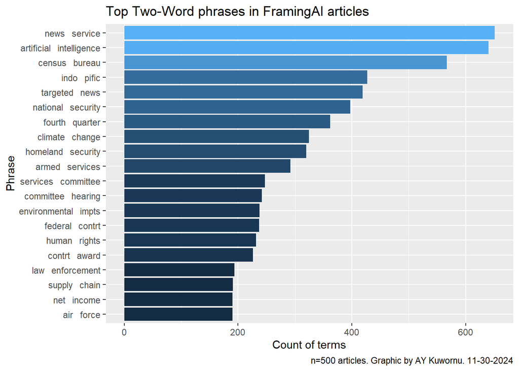

```r
ggplot(top_20_bigrams, aes(x = reorder(bigram, n), y = n, fill=n)) +
  geom_bar(stat = "identity") +
  theme(legend.position = "none") +
  coord_flip() +
  labs(title = "Top Two-Word phrases in FramingAI articles",
       caption = "n=500 articles. Graphic by AY Kuwornu. 11-30-2024",
       x = "Phrase",
       y = "Count of terms")
```

#Sentiment Analysis

```r
library(textdata)
library(quanteda)
```

#Tokenize text

```r
text_tokenized <- articles_df %>%
  select(sentence) %>%
  unnest_tokens(word, sentence)
```

#Filter tokenized text

```r
text_tokenized <- articles_df %>%
  select(sentence) %>%
  mutate(sentence = str_replace_all(sentence, "- ", "")) %>%
  unnest_tokens(word, sentence) %>%
  filter(!word %in% stop_words$word) %>%
  filter(word != "stories_corpus") %>%
  filter(!grepl('[0-9]', word))
```

#Do a word count

```r
text_word_ct <- text_tokenized %>%
  count(word, sort=TRUE)
text_word_ct
```

```
## # A tibble: 32,357 × 2
##    word          n
##    <chr>     <int>
##  1 u.s        3455
##  2 security   3001
##  3 ai         2885
##  4 data       2876
##  5 page       2660
##  6 including  2177
##  7 support    2094
##  8 services   1845
##  9 global     1811
## 10 million    1795
## # ℹ 32,347 more rows
```

#Load NRC lexicon

```r
nrc_sentiments <- get_sentiments("nrc")

nrc_sentiments %>% count(sentiment)
```

```
## # A tibble: 10 × 2
##    sentiment        n
##    <chr>        <int>
##  1 anger         1245
##  2 anticipation   837
##  3 disgust       1056
##  4 fear          1474
##  5 joy            687
##  6 negative      3316
##  7 positive      2308
##  8 sadness       1187
##  9 surprise       532
## 10 trust         1230
```

```r
nrc_sentiments %>%
  group_by(word) %>%
  count() %>%
  arrange(desc(n)) %>%
  distinct()
```

```
## # A tibble: 6,453 × 2
## # Groups:   word [6,453]
##    word          n
##    <chr>     <int>
##  1 feeling      10
##  2 treat        10
##  3 weight        9
##  4 celebrity     8
##  5 intense       8
##  6 obliging      8
##  7 opera         8
##  8 supremacy     8
##  9 vote          8
## 10 death         7
## # ℹ 6,443 more rows
```

# Count Overall Sentiment with NRC

```r
sentiments_all <- text_tokenized %>%
  inner_join(nrc_sentiments)
sentiments_all %>%
  group_by(word) %>%
    count(sentiment) %>%
  arrange(desc(n))
```

```
## # A tibble: 7,238 × 3
## # Groups:   word [3,336]
##    word        sentiment        n
##    <chr>       <chr>        <int>
##  1 including   positive      2177
##  2 technology  positive      1773
##  3 information positive      1724
##  4 united      positive      1690
##  5 united      trust         1690
##  6 defense     anger         1492
##  7 defense     anticipation  1492
##  8 defense     fear          1492
##  9 defense     positive      1492
## 10 march       positive      1340
## # ℹ 7,228 more rows
```

```r
sentiments_all <- text_tokenized %>%
  inner_join(nrc_sentiments) %>%
  count(sentiment, sort = TRUE) %>%
  mutate(pct_total =round(n/sum(n), digits=2))
sentiments_all
```

```
## # A tibble: 10 × 3
##    sentiment        n pct_total
##    <chr>        <int>     <dbl>
##  1 positive     94619      0.31
##  2 trust        55417      0.18
##  3 negative     33580      0.11
##  4 anticipation 30210      0.1
##  5 fear         27184      0.09
##  6 joy          18825      0.06
##  7 anger        17091      0.06
##  8 sadness      12551      0.04
##  9 surprise      9234      0.03
## 10 disgust       7315      0.02
```

# Create ggplot

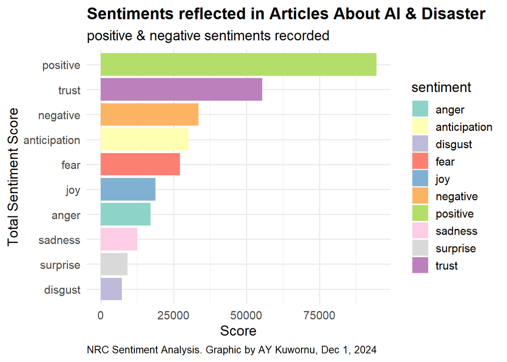

```r
# Load necessary libraries
library(ggplot2)
library(dplyr)

# Plot the sentiment analysis results
nrc_plot <- sentiments_all %>%
  ggplot(aes(x = reorder(sentiment, n), y = n, fill = sentiment)) +
  geom_bar(stat = "identity", position = "dodge") +
  theme(legend.position = "none") +
  labs(
    title = "Sentiments reflected in Articles About AI & Disaster",
    subtitle = "positive & negative sentiments recorded ",
    caption = "NRC Sentiment Analysis. Graphic by AY Kuwornu, Dec 1, 2024",
    x = "Total Sentiment Score",
    y = "Score"
  ) +
  theme_minimal(base_size = 14) +
  theme(
    plot.title = element_text(face = "bold", size = 16),
    plot.caption = element_text(hjust = 0, size = 10)
  ) +
  scale_fill_brewer(palette = "Set3") +
  coord_flip()
# Print the plot
print(nrc_plot)
```

#Check the words in some of the sentiments

#Positive

```r
nrc_positive <- nrc_sentiments %>%
  filter(sentiment == "positive")
FramingAI_positive <- text_tokenized %>%
  inner_join(nrc_positive) %>%
  count(word, sort = TRUE)
FramingAI_positive
```

```
## # A tibble: 1,409 × 2
##    word             n
##    <chr>        <int>
##  1 including     2177
##  2 technology    1773
##  3 information   1724
##  4 united        1690
##  5 defense       1492
##  6 march         1340
##  7 intelligence  1095
##  8 community     1077
##  9 public        1051
## 10 management    1010
## # ℹ 1,399 more rows
```

#Trust

```r
#Trust
nrc_trust <- nrc_sentiments %>%
  filter(sentiment == "trust")
FramingAI_trust <- text_tokenized %>%
  inner_join(nrc_trust) %>%
  count(word, sort = TRUE)
FramingAI_trust
```

```
## # A tibble: 808 × 2
##    word             n
##    <chr>        <int>
##  1 united        1690
##  2 intelligence  1095
##  3 management    1010
##  4 committee      982
##  5 provide        962
##  6 continue       936
##  7 cooperation    927
##  8 president      904
##  9 system         878
## 10 law            855
## # ℹ 798 more rows
```

#Negative

```r
nrc_negative <- nrc_sentiments %>%
  filter(sentiment == "negative")
FramingAI_negative <- text_tokenized %>%
  inner_join(nrc_negative) %>%
  count(word, sort = TRUE)
FramingAI_negative
```

```
## # A tibble: 1,447 × 2
##    word           n
##    <chr>      <int>
##  1 government  1124
##  2 disaster    1018
##  3 force        990
##  4 risk         933
##  5 income       833
##  6 foreign      790
##  7 hearing      655
##  8 words        613
##  9 loss         560
## 10 armed        439
## # ℹ 1,437 more rows
```

#Fear

```r
nrc_fear <- nrc_sentiments %>%
  filter(sentiment == "fear")
FramingAI_fear <- text_tokenized %>%
  inner_join(nrc_fear) %>%
  count(word, sort = TRUE)
FramingAI_fear
```

```
## # A tibble: 757 × 2
##    word             n
##    <chr>        <int>
##  1 defense       1492
##  2 military      1156
##  3 government    1124
##  4 intelligence  1095
##  5 disaster      1018
##  6 force          990
##  7 risk           933
##  8 change         724
##  9 hearing        655
## 10 loss           560
## # ℹ 747 more rows
```

#Anticipation

```r
nrc_anticipation <- nrc_sentiments %>%
  filter(sentiment == "anticipation")
FramingAI_anticipation <- text_tokenized %>%
  inner_join(nrc_anticipation) %>%
  count(word, sort = TRUE)
FramingAI_anticipation
```

```
## # A tibble: 531 × 2
##    word           n
##    <chr>      <int>
##  1 defense     1492
##  2 time        1175
##  3 public      1051
##  4 continue     936
##  5 risk         933
##  6 income       833
##  7 university   615
##  8 network      604
##  9 improve      554
## 10 share        547
## # ℹ 521 more rows
```

#Anger

```r
nrc_anger <- nrc_sentiments %>%
  filter(sentiment == "anger")
FramingAI_anger <- text_tokenized %>%
  inner_join(nrc_anger) %>%
  count(word, sort = TRUE)
FramingAI_anger
```

```
## # A tibble: 633 × 2
##    word         n
##    <chr>    <int>
##  1 defense   1492
##  2 disaster  1018
##  3 force      990
##  4 words      613
##  5 loss       560
##  6 armed      439
##  7 demand     376
##  8 violence   336
##  9 cash       326
## 10 conflict   323
## # ℹ 623 more rows
```

```r
library(dplyr)
library(tidyr)
library(ggplot2)

# Define sentiments to analyze
sentiments <- c("positive", "trust", "negative", "fear", "anticipation", "anger")

# Process each sentiment and combine results into a single table
final_table <- lapply(sentiments, function(sentiment) {
  nrc_sentiments %>%
    filter(sentiment == !!sentiment) %>%
    inner_join(text_tokenized, by = "word") %>%
    count(word, sort = TRUE) %>%
    mutate(sentiment = sentiment)
}) %>%
  bind_rows() %>%
  pivot_wider(names_from = sentiment, values_from = n, values_fill = 0)

# View final table
print(final_table)
```

```
## # A tibble: 3,261 × 7
##    word         positive trust negative  fear anticipation anger
##    <chr>           <int> <int>    <int> <int>        <int> <int>
##  1 including        2177     0        0     0            0     0
##  2 technology       1773     0        0     0            0     0
##  3 information      1724     0        0     0            0     0
##  4 united           1690  1690        0     0            0     0
##  5 defense          1492     0        0  1492         1492  1492
##  6 march            1340     0        0     0            0     0
##  7 intelligence     1095  1095        0  1095            0     0
##  8 community        1077     0        0     0            0     0
##  9 public           1051     0        0     0         1051     0
## 10 management       1010  1010        0     0            0     0
## # ℹ 3,251 more rows
```

#In this part, i used the excel data downloaded from NexisUni to generate some useful statistics

#Create ggplot chart showing the distribution of the data over time

#Import the excel file

```r
library(tidyverse)
AI_disaster  <- rio::import("../AYClassProjectRepo/AY_framingAI.XLSX") %>%
  janitor::clean_names()
head(AI_disaster)
```

```
##                                                                                                                                                                                                title
## 1 TOP TEN FOR TWENTY FOUR A YEAR OF POLITICAL CHANGE, ECONOMIC CLOUDS GRADUALLY LIFTING, DEBT PROBLEMS LINGERING, ENGLAND FAVOURITES FOR A SOCCER COMPETITION, AND BREAK DANCING A NEW OLYMPIC SPORT
## 2                                                                                               EPA AWARDS $200,000 TO LOS ANGELES SMALL BUSINESSES TO ADVANCE INNOVATIVE ENVIRONMENTAL TECHNOLOGIES
## 3                                                                                               EPA Awards $200,000 to Los Angeles Small Businesses to Advance Innovative Environmental Technologies
## 4                                                                                                                                                              2023 UNM RESEARCH NEWS YEAR-IN-REVIEW
## 5                                                                                                                                 TeraWulf Announces December 2023 Production and Operations Updates
## 6                                                                                                                                                                        NTIA 2023: A YEAR IN REVIEW
##              published_date publication_location         publication_4
## 1    January 1, 2024 Monday         U.S. Federal   States News Service
## 2   January 2, 2024 Tuesday         U.S. Federal           US Fed News
## 3   January 2, 2024 Tuesday         U.S. Federal Targeted News Service
## 4   January 2, 2024 Tuesday         U.S. Federal           US Fed News
## 5 January 3, 2024 Wednesday         U.S. Federal         GlobeNewswire
## 6  January 4, 2024 Thursday         U.S. Federal   States News Service
##   publication_type_5 length    section word_count countries
```

[output cut: 41 more lines]

#I am presenting ggplot based on per week data.

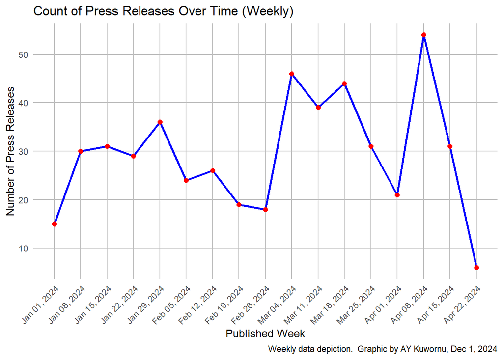

```r
library(tidyverse)
library(janitor)
library(lubridate)

# Clean and preprocess the data
AI_ggplot <- AI_disaster |>
  janitor::clean_names() |>
  mutate(published_date_bak = published_date) |>
  separate(published_date, into = c("date", "year_day"), sep = ", ", extra = "merge", fill = "right") |>
  mutate(date = as.Date(date, format = "%B %d")) |> # Convert to proper date format
  mutate(week = floor_date(date, unit = "week", week_start = 1)) |> # Group by week (starting on Monday)
  group_by(week) |>
  count(week)

# Plotting the data
ggplot(AI_ggplot, aes(x = week, y = n)) +
  geom_line(color = "blue", size = 1) +
  geom_point(color = "red", size = 2) +
  scale_x_date(date_labels = "%b %d, %Y", date_breaks = "1 week") + # Show labels for every week
  labs(
    title = "Count of Press Releases Over Time (Weekly)",
    caption = "Weekly data depiction.  Graphic by AY Kuwornu, Dec 1, 2024",
    x = "Published Week",
    y = "Number of Press Releases"
  ) +
  theme_minimal() +
  theme(
    axis.text.x = element_text(angle = 45, hjust = 1),
    panel.grid.major = element_line(size = 0.5, color = "gray"),
    panel.grid.minor = element_blank()
  )
```

#Where most Press Release published

```r
pr_published_by <- AI_disaster %>%
  count(publication_4) %>%
  group_by(publication_4) %>%
  summarise(pr_published_by = sum(n)) %>%
  arrange(desc(pr_published_by)) %>%
 head(10)
```

#Visualize top 10

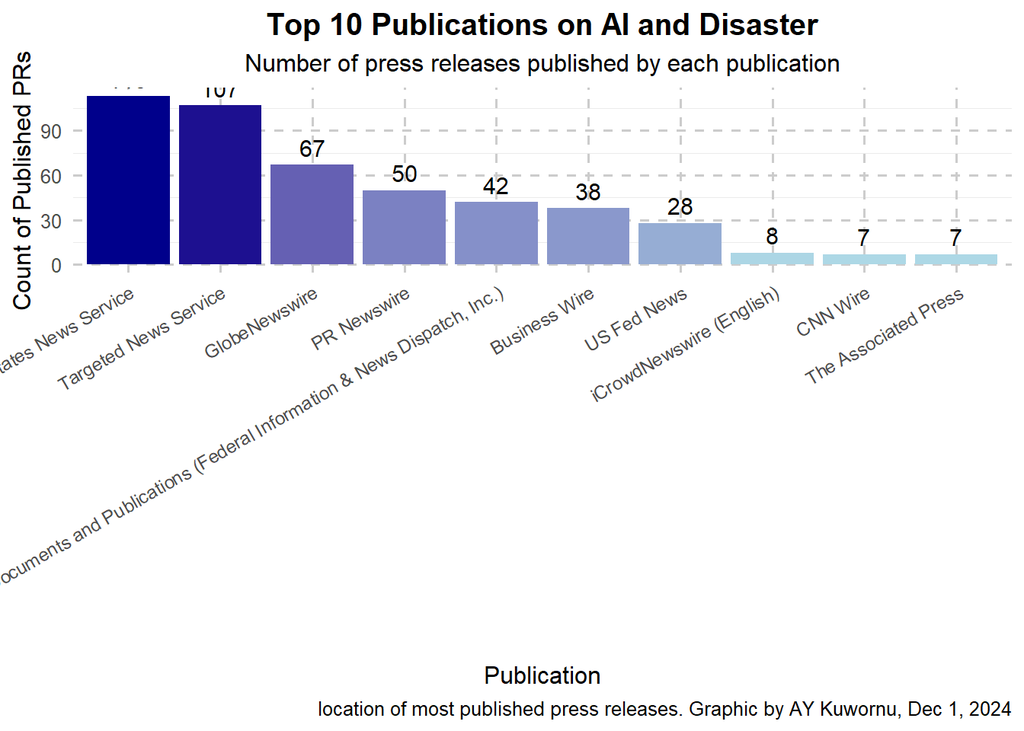

```r
# Assuming `pr_published_by` is already created as per your code
library(ggplot2)
library(ggthemes) # For additional themes

# Create a better-looking bar chart
ggplot(pr_published_by, aes(x = reorder(publication_4, -pr_published_by), y = pr_published_by, fill = pr_published_by)) +
  geom_bar(stat = "identity", show.legend = FALSE) +
  geom_text(aes(label = pr_published_by), vjust = -0.5, size = 4, color = "black") +
  scale_fill_gradient(low = "lightblue", high = "darkblue") +
  theme_minimal(base_size = 12) +
  labs(
    title = "Top 10 Publications on AI and Disaster",
    subtitle = "Number of press releases published by each publication",
    caption = "location of most published press releases. Graphic by AY Kuwornu, Dec 1, 2024",
    x = "Publication",
    y = "Count of Published PRs"
  ) +
  theme(
    plot.title = element_text(face = "bold", size = 15, hjust = 0.5),
    plot.subtitle = element_text(size = 12, hjust = 0.5),
    axis.text.x = element_text(angle = 30, hjust = 1, size = 9),
    panel.grid.major = element_line(color = "grey80", linetype = "dashed")
  )
```

```r
# install.packages("here")
# install.packages("tidytext")
# install.packages("quanteda")
# install.packages("tm")
# install.packages("topicmodels")
# install.packages("reshape2")
# install.packages("ggplot2")
# install.packages("wordcloud")
# install.packages("pals")
# install.packages("SnowballC")
# install.packages("lda")
# install.packages("ldatuning")
# install.packages("kableExtra")
# install.packages("DT")
# install.packages("flextable")
# install.packages("remotes")
# remotes::install_github("rlesur/klippy")
#install.packages("rio")
#install.packages("readtext")
#install.packages("formattable")
```

### Import Data and process into corpus

```r
topic_data <- articles_df %>%
  select(filename, sentence) %>%
  as.data.frame() %>%
  rename(doc_id = filename, text= sentence)

# load stopwords
english_stopwords <- readLines("https://slcladal.github.io/resources/stopwords_en.txt", encoding = "UTF-8")
# create corpus object
corpus <- Corpus(DataframeSource(topic_data))
# Preprocessing chain
processedCorpus <- tm_map(corpus, content_transformer(tolower))
processedCorpus <- tm_map(processedCorpus, removeWords, english_stopwords)
processedCorpus <- tm_map(processedCorpus, removePunctuation, preserve_intra_word_dashes = TRUE)
processedCorpus <- tm_map(processedCorpus, removeNumbers)
processedCorpus <- tm_map(processedCorpus, stemDocument, language = "en")
processedCorpus <- tm_map(processedCorpus, stripWhitespace)
```

```r
#DTM: rows correspond to the documents in the corpus. Columns correspond to the terms in the documents. Cells correspond to the weights of the terms. (Girder)
# compute document term matrix with terms >= minimumFrequency
minimumFrequency <- 5
DTM <- DocumentTermMatrix(processedCorpus, control = list(bounds = list(global = c(minimumFrequency, Inf))))
# have a look at the number of documents and terms in the matrix
dim(DTM)
```

```
## [1] 98885  7993
```

```r
# due to vocabulary pruning, we have empty rows in our DTM
# LDA does not like this. So we remove those docs from the
# DTM and the metadata
sel_idx <- slam::row_sums(DTM) > 0
DTM <- DTM[sel_idx, ]
topic_data <- topic_data[sel_idx, ]
#5 term minimum[1] 1387 3019
#5 term minimum[1] 308597 10339
```

```r
# number of topics
# K <- 20
K <- 6
# set random number generator seed
set.seed(9161)
#Latent Dirichlet Allocation, LDA
topicModel2 <- LDA(DTM, K, method="Gibbs", control=list(iter = 1000, verbose = 25, alpha = 0.2))
```

```
## K = 6; V = 7993; M = 94310
## Sampling 1000 iterations!
## Iteration 25 ...
## Iteration 50 ...
## Iteration 75 ...
## Iteration 100 ...
## Iteration 125 ...
## Iteration 150 ...
## Iteration 175 ...
## Iteration 200 ...
## Iteration 225 ...
## Iteration 250 ...
## Iteration 275 ...
## Iteration 300 ...
## Iteration 325 ...
## Iteration 350 ...
## Iteration 375 ...
## Iteration 400 ...
## Iteration 425 ...
## Iteration 450 ...
## Iteration 475 ...
## Iteration 500 ...
## Iteration 525 ...
## Iteration 550 ...
## Iteration 575 ...
## Iteration 600 ...
## Iteration 625 ...
## Iteration 650 ...
## Iteration 675 ...
## Iteration 700 ...
## Iteration 725 ...
## Iteration 750 ...
## Iteration 775 ...
## Iteration 800 ...
## Iteration 825 ...
## Iteration 850 ...
## Iteration 875 ...
## Iteration 900 ...
## Iteration 925 ...
## Iteration 950 ...
## Iteration 975 ...
## Iteration 1000 ...
## Gibbs sampling completed!
```

```r
tmResult <- posterior(topicModel2)
theta <- tmResult$topics
beta <- tmResult$terms
topicNames <- apply(terms(topicModel2, 10), 2, paste, collapse = " ")  # reset topicnames
```

### Extracting and visualizing the topics

```r
# Step 1: Check dimensions
n_theta <- nrow(theta)
n_topicdata<- length(topic_data)

cat("Number of rows in theta: ", n_theta, "\n")
```

```
## Number of rows in theta:  94310
```

```r
cat("Number of documents in textdata: ", n_topicdata, "\n")
```

```
## Number of documents in textdata:  2
```

```r
# Check if textdata contains all the documents in theta
common_ids <- intersect(rownames(theta), topic_data$doc_id) # Assuming textdata has a 'doc_id' column

# Filter textdata to include only the documents present in theta
topicdata_filtered <- topic_data[topic_data$doc_id %in% common_ids, ]

# Check dimensions after filtering
n_topicdata_filtered <- nrow(topicdata_filtered)
cat("Number of documents in filtered textdata: ", n_topicdata_filtered, "\n")
```

```
## Number of documents in filtered textdata:  94310
```

```r
# Align rownames of theta with filtered textdata
theta_aligned <- theta[rownames(theta) %in% topicdata_filtered$doc_id, ]

# Step 2: Combine data
full_data <- data.frame(theta_aligned, decade = topicdata_filtered)

# get mean topic proportions per decade
# topic_proportion_per_decade <- aggregate(theta, by = list(decade = textdata$decade), mean)
# set topic names to aggregated columns
colnames(full_data)[2:(K+1)] <- topicNames
# reshape data frame
vizDataFrame <- melt(full_data)
#Examine topic names
#enframe(): Converts a named list into a dataframe.
topics <- enframe(topicNames, name = "number", value = "text") %>%
  unnest(cols = c(text))

topics
```

```
## # A tibble: 6 × 2
##   number  text
##   <chr>   <chr>
## 1 Topic 1 technolog develop energi impact global climat research innov resili e…
## 2 Topic 2 page march presid committe state hous washington april hear februari
## 3 Topic 3 data busi servic provid compani solut technolog product manag census
## 4 Topic 4 program servic fund support state million communiti news health includ
## 5 Topic 5 year result financi oper report net loss quarter includ million
## 6 Topic 6 forc china secur region state partner unit continu oper support
```

# Review the topics and determine a 1-2 word label after reading the source documents.

```r
theta2 <- as.data.frame(theta)

topic1 <- theta2 %>%
  rownames_to_column(var = "file") |> # putting the rownames into a new column called file
  mutate(file = str_remove(file, "^X"),  # Remove leading 'X'
         line = str_extract(file, "(?<=\\.txt)\\.\\d+")) |>   # Extract number after .txt
  mutate(file = str_remove(file, "\\.\\d+$")) |>
  rename(topic1 = '1') |>
  top_n(20, topic1) |>
  arrange(desc(topic1)) |>
  select(file, line, topic1)
```

```r
vizDataFrame <- vizDataFrame %>%
  mutate(category = case_when(
    str_detect(variable, "data technolog servic manag provid system market cloud intellig comput") ~ "managing crisis",
    str_detect(variable, "servic program communiti develop support health energi news includ climat") ~ "community engagement",
    str_detect(variable, "committe depart state hous year issu act fund offic report") ~ "government involvement",
    str_detect(variable, "state secur unit support cooper region continu countri forc commit") ~ "approach",
    str_detect(variable, "year result oper million financi quarter net compani increas includ") ~ "outcome",
    str_detect(variable, "page presid census time peopl word length load-dat bureau american
") ~ "reflection",
    TRUE ~ NA_character_  # Ensure there is a default value for non-matching cases
  ))
```

## 800 word analysis

#What themes and narratives dominate discussions of AI in the context of natural disasters and crises? In assessing the themes and dominant narrative regarding AI and crisis or natural disasters, the reflection was the readiness of various government institutions to deal with crisis. The defense department, environmental protection agency, are among some of the government institutions that projected a readiness to step into disaster situations. A cursory review of the releases showed the prevalence of themes such as disaster recovery, rescue, government support, etc in these press releases. But the biagrams also showed the dominance of government organizations in the discussion of crisis. Technology also featured prominently, referring to crisis related to technology. The narratives centered mainly around how these organizations responded to disasters and crisis.

#What potential risks and ethical concerns regarding AI usage are highlighted in these communications? The analysis did not quite show the risks and ethical concerns regarding AI use in the press releases reviewed. This could be due to the fact that the press releases did not address AI use specifically but in most instances, referred to the effect of AI in their disaster/crisis response strategies.